# NFL Current Team Summary Statistics

Steven Griffin

December 6th, 2017

*Source file* ⇒ Final_Project_for_Stat_184.Rmd

# Introduction

For my final project I decided to focus on summarizing the current team statistics in the NFL. While it was initially due to my love of football (FLY EAGLES FLY!) I soon saw the potential analyzing such a dataset could have when predicting future win percentages of teams and tracking their overall winning and losing trends. In this analysis, I am looking at all 32 teams in the NFL and their statistics for each position.

# Scraping of Current 2017 NFL Team Statistics

```r
xpath<-'//*[@id="my-teams-table"]/div/div[2]/table'
Scrape1<-"http://www.espn.com/nfl/statistics/team/_/stat/passing"
Table_list1<-
  Scrape1%>%
  read_html()%>%
  html_nodes(xpath=xpath)%>%
  html_table(fill=TRUE)
PassingTot2017<-Table_list1[[1]]
Scrape2<-"http://www.espn.com/nfl/statistics/team/_/stat/rushing"
Table_list2<-
  Scrape2%>%
  read_html()%>%
  html_nodes(xpath=xpath)%>%
  html_table(fill=TRUE)
RushingTot2017<-Table_list2[[1]]
Scrape3<-"http://www.espn.com/nfl/statistics/team/_/stat/receiving"
Table_list3<-
  Scrape3%>%
  read_html()%>%
  html_nodes(xpath=xpath)%>%
  html_table(fill=TRUE)
RecievingTot2017<-Table_list3[[1]]
Scrape4<-"http://www.espn.com/nfl/statistics/team/_/stat/returning"
Table_list4<-
  Scrape4%>%
  read_html()%>%
  html_nodes(xpath=xpath)%>%
  html_table(fill=TRUE)
ReturningTot2017<-Table_list4[[1]]
Scrape5<-"http://www.espn.com/nfl/statistics/team/_/stat/kicking"
Table_list5<-
  Scrape5%>%
  read_html()%>%
  html_nodes(xpath=xpath)%>%
  html_table(fill=TRUE)
KickingTot2017<-Table_list5[[1]]
Scrape6<-"http://www.espn.com/nfl/statistics/team/_/stat/punting"
Table_list6<-
  Scrape6%>%
  read_html()%>%
  html_nodes(xpath=xpath)%>%
  html_table(fill=TRUE)
PuntingTot2017<-Table_list6[[1]]
Scrape7<-"http://www.espn.com/nfl/statistics/team/_/stat/defense"
Table_list7<-
  Scrape7%>%
  read_html()%>%
  html_nodes(xpath=xpath)%>%
  html_table(fill=TRUE)
DefenseTot2017<-Table_list7[[1]]
LeagueStandings2017<-read.table(file="clipboard",sep = "\t",header = TRUE)
```

# Forming Total Team Statistics Tables

```r
NamesDefense<-c("RANK","TEAM","TACK_SOLO2","TACK_AST2", "TACK_TOT2","SACK_SACK2","SACK_YDSL2","INTERCEPT_PD", "INTERCEPT_INT", "INTERCEPT_YDS", "INTERCEPT_LONG", "INTERCEPT_TD", "FUMBLES_FF", "FUMBLES_REC", "FUMBLES_TD")
DefenseTot2017<-`colnames<-`(DefenseTot2017,NamesDefense)
NamesPassing<-c("RANK","TEAM","ATT1","COMP1", "PCT1","YDS1","YDS-A1","LONG1", "TD1", "INT1", "SACK1", "YDSL1", "RATE1", "YDS-G1")
PassingTot2017<-`colnames<-`(PassingTot2017,NamesPassing)
NamesPunting<-c("RANK","TEAM","PUNTS3","YDS3", "LNG3","PUNTAVG3","NET3","BP3", "IN203", "TB3", "FC3", "RET3", "RETY3", "RETAVG3")
PuntingTot2017<-`colnames<-`(PuntingTot2017,NamesPunting)
NamesKicking<-c("RANK","TEAM","FG_FGM4","FG_FGA4", "FG_PCT4","FG_LNG 4","FG_1-19","FG_20-29", "FG_30-39", "FG_40-49", "FG_50+", "YDSL1EP_XPM4", "EP_XPA4", "EP_PCT","NA1","NA2","NA3")
KickingTot2017<-`colnames<-`(KickingTot2017,NamesKicking)
NamesReturning<-c("RANK","TEAM","KICKATT6","KICKYDS6", "KICKAVG6","KICKLNG6","KICKTD6","PUNTSATT6", "PUNTSYDS6", "PUNTSAVG6","PUNTSLNG6","PUNTSTD6","PUNTSFC6")
ReturningTot2017<-`colnames<-`(ReturningTot2017,NamesReturning)
NamesRecieving<-c("RANK","TEAM", "REC5","YDS5","AVG5","LONG5","TD5","YDS-G5","FUM5","FUML5")
RecievingTot2017<-`colnames<-`(RecievingTot2017,NamesRecieving)
NamesRushing<-c("RANK","TEAM", "ATT7","YDS7","YDS-A7","LONG7","TD7","YDS-G7","FUM7","FUML7")
RushingTot2017<-`colnames<-`(RushingTot2017,NamesRushing)
```

# Joining the Tables

Tables were then merged based on the team that the data corresponded to. This gave me a single table that I could use to produce plots with ggplot as well as the beginning steps towards a decision tree to decide the winning to total game ratio of a given team in 2017.

```r
DefKick<-merge(DefenseTot2017,KickingTot2017,by="TEAM")
DefKick$RANK.x<-NULL
DefKick$RANK.y<-NULL
PassPunt<-merge(PassingTot2017,PuntingTot2017,by="TEAM")
PassPunt$RANK.x<-NULL
PassPunt$RANK.y<-NULL
RecRet<-merge(RecievingTot2017,ReturningTot2017,by="TEAM")
RecRet$RANK.x<-NULL
RecRet$RANK.y<-NULL
DKPP<-merge(DefKick,PassPunt,by="TEAM")
RRRush<-merge(RushingTot2017,RecRet,by="TEAM")
RRRush$RANK<-NULL
RRRushLeag<-merge(LeagueStandings2017, RRRush,by="TEAM")
TotTeamData2017<-merge(RRRushLeag,DKPP,by="TEAM")
TotTeamData2017$NA1<-NULL
TotTeamData2017$NA2<-NULL
TotTeamData2017$NA3<-NULL
TotTeamData2017
```

```
##             TEAM WIN LOSS TIE   PCT ABVAVGP ABVAVGR ABVAVGT ABVAVGS ATT7
## 1        Arizona   5    7   0 0.417   green     red     red   green  287
## 2        Atlanta   7    5   0 0.583   green   green   green   green  312
## 3      Baltimore   7    5   0 0.583     red   green     red   green  345
## 4        Buffalo   6    6   0 0.500     red   green   green     red  350
## 5       Carolina   8    4   0 0.667     red   green     red   green  361
## 6        Chicago   3    9   0 0.250     red   green     red   green  323
## 7     Cincinnati   5    7   0 0.417     red     red   green   green  280
## 8      Cleveland   0   12   0 0.000     red     red   green     red  291
## 9         Dallas   6    6   0 0.500     red   green     red   green  356
## 10        Denver   3    9   0 0.250     red     red     red     red  318
## 11       Detroit   6    6   6 0.500   green     red     red     red  280
## 12     Green Bay   6    6   0 0.500     red     red   green   green  289
## 13       Houston   4    8   0 0.333   green   green     red     red  349
## 14  Indianapolis   3    9   0 0.250     red     red     red     red  323
```

[output cut: 315 more lines]

# 2017 Plots

### Passing Yards Per Game

Since football can be dumbed down down to the team that is able to gain the most yards winning the game (more yards means closer to the endzone), I decided to graph the passing yards generally obtained per game by a team and the average rushing yards per game. With this I also added a red, dashed, line to mark the mean average of passing and rushing yards per game in the NFL currently. Color was added to define if the teams statistics were above the average for the NFL in 2017. This was also added to the data table.

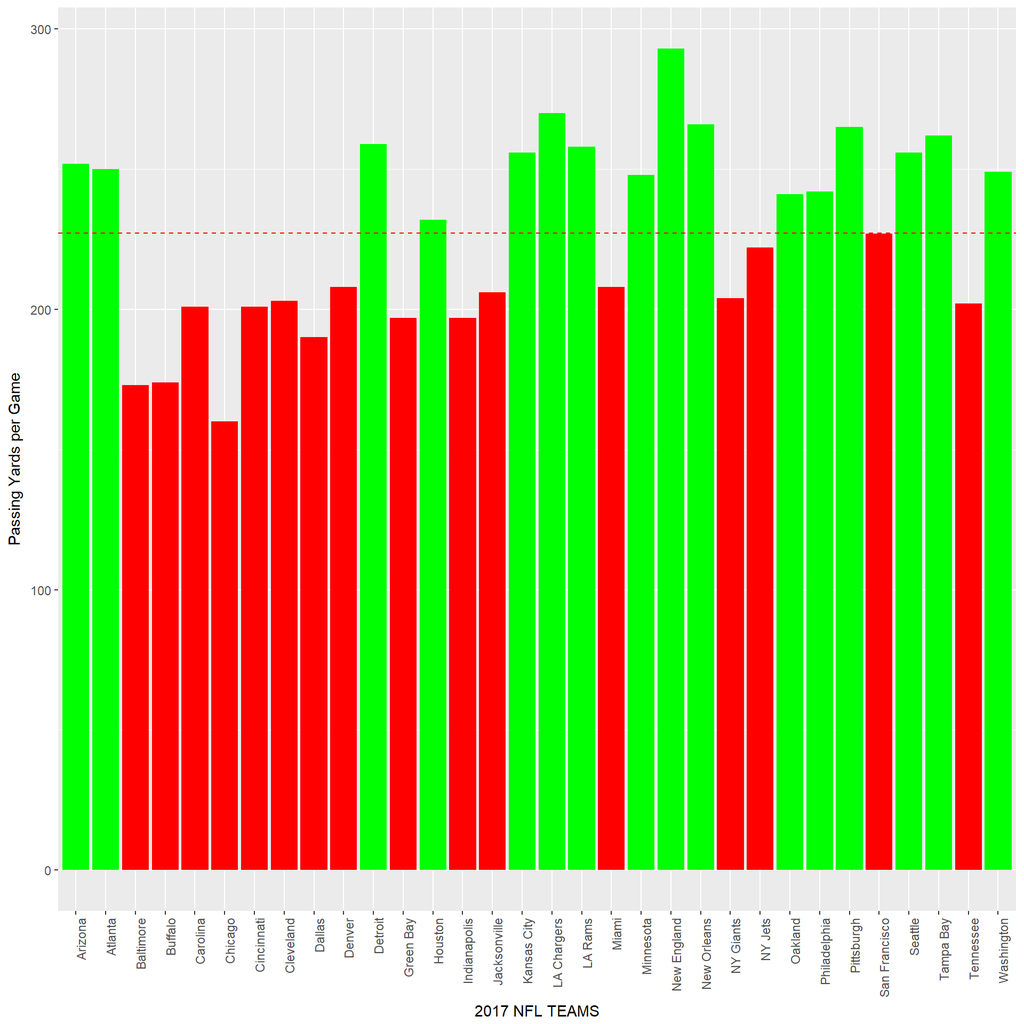

```r
ggplot(data = TotTeamData2017, aes(x=TotTeamData2017$TEAM, y=as.numeric(TotTeamData2017$`YDS-G1`)))+
  geom_bar(stat = "identity",fill=TotTeamData2017$ABVAVGP)+
  xlab("2017 NFL TEAMS")+
  ylab("Passing Yards per Game")+
  theme(axis.text.x = element_text(angle = 90,hjust = 1))+
  geom_hline(yintercept = mean(as.numeric(TotTeamData2017$`YDS-G1`)), linetype="dashed", color="red")
```

### Rushing Yards per Game

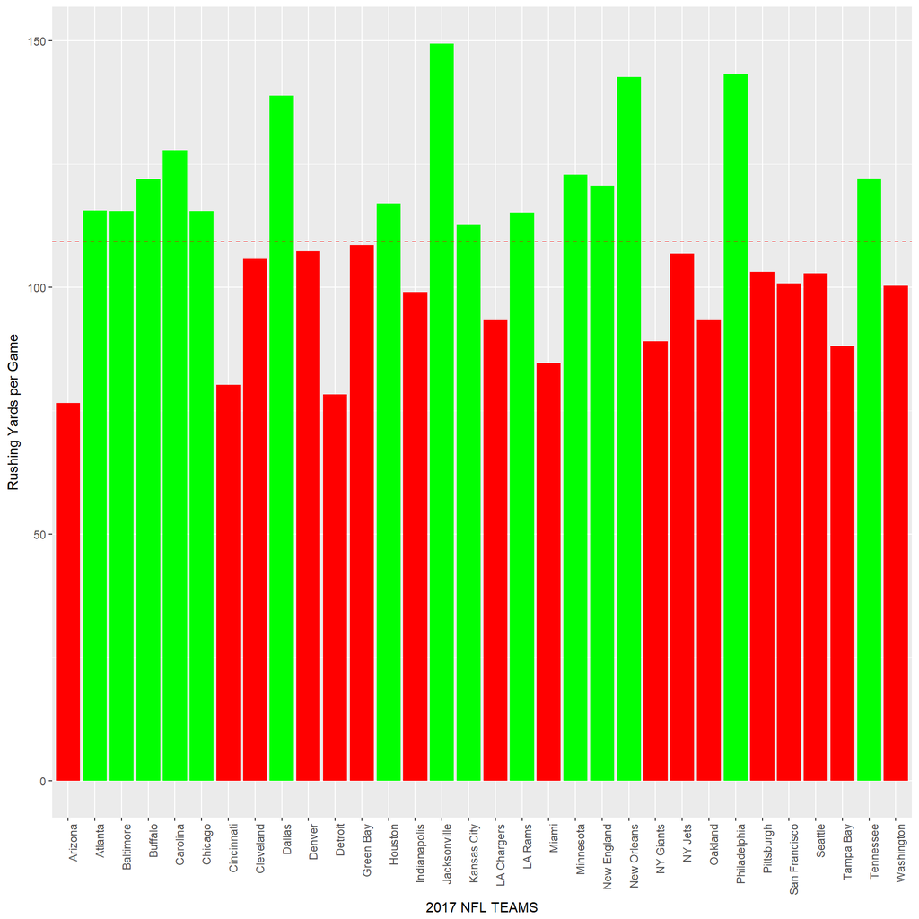

```r
ggplot(data = TotTeamData2017, aes(x=TotTeamData2017$TEAM, y=as.numeric(TotTeamData2017$`YDS-G7`)))+
  geom_bar(stat = "identity",fill=TotTeamData2017$ABVAVGR)+
  xlab("2017 NFL TEAMS")+
  ylab("Rushing Yards per Game")+
  theme(axis.text.x = element_text(angle = 90,hjust = 1))+
  geom_hline(yintercept = mean(as.numeric(TotTeamData2017$`YDS-G7`)) , linetype="dashed", color="red")
```

### Total Tackles for the Season

Similar to the last two graphs, preventing the other team from gaining yards is pertinant to winning the game. For this I decided to look at total tackles as well as the yards the opponent lost due to the teams defense from a sack.

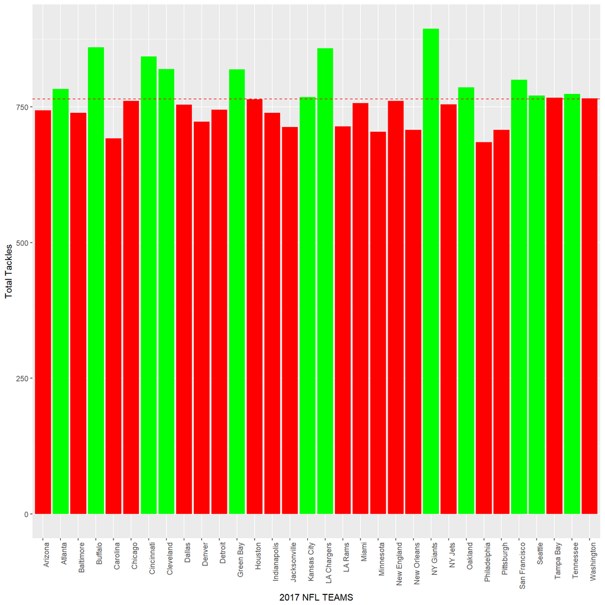

```r
ggplot(data = TotTeamData2017, aes(x=TotTeamData2017$TEAM, y=as.numeric(TotTeamData2017$`TACK_TOT2`)))+
  geom_bar(stat = "identity", fill=TotTeamData2017$ABVAVGT)+
  xlab("2017 NFL TEAMS")+
  ylab("Total Tackles")+
  theme(axis.text.x = element_text(angle = 90,hjust = 1))+
  geom_hline(yintercept = mean(as.numeric(TotTeamData2017$`TACK_TOT2`)) , linetype="dashed", color="red")
```

### Yards Opponents Lost Due to Sacks

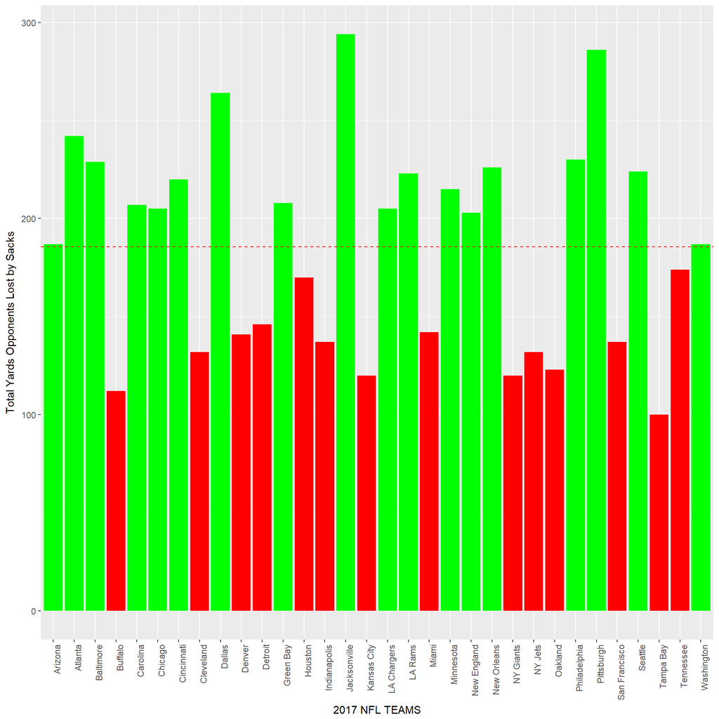

```r
ggplot(data = TotTeamData2017, aes(x=TotTeamData2017$TEAM, y=as.numeric(TotTeamData2017$`SACK_YDSL2`)))+
  geom_bar(stat = "identity",fill=TotTeamData2017$ABVAVGS)+
  xlab("2017 NFL TEAMS")+
  ylab("Total Yards Opponents Lost by Sacks")+
  theme(axis.text.x = element_text(angle = 90,hjust = 1))+
  geom_hline(yintercept = mean(as.numeric(TotTeamData2017$`SACK_YDSL2`)) , linetype="dashed", color="red")
```

If we take the NE Patriots (Previous Superbowl winners) and a prospective Superbowl team like the Eagles (fan favorite), we see that both are above average for offensive aspects as well as sacks. Considering how close the values are for total tackles we can consider such a facter not as pertinant as the others in determining high win percentages.

# Decision Tree for Win Percentages of 2017

I tried to show how the win percentage of a team could be determined through the teams statistics. A problem occured when only two factors would be present on the tree at one time. I believe this is due in part to the lack of variations present with the win percentages between teams. Looking to the future, I would consider obtaining data from later dates (possibly 10 years back) and use that to fill out the decision tree with more variables.

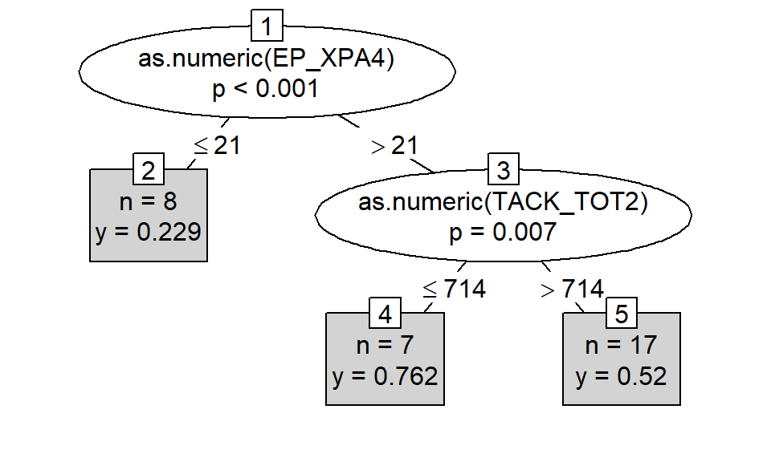

```r
mod1<-ctree(as.numeric(PCT)~as.numeric(EP_XPA4)+as.numeric(TACK_TOT2),data=TotTeamData2017)
plot(mod1, type="simple")
```

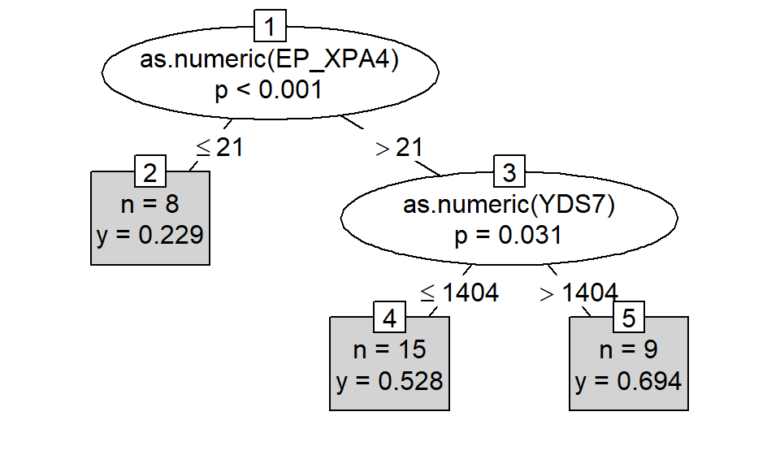

```r
mod1<-ctree(as.numeric(PCT)~as.numeric(YDS7)+as.numeric(EP_XPA4),data=TotTeamData2017)
plot(mod1, type="simple")
```

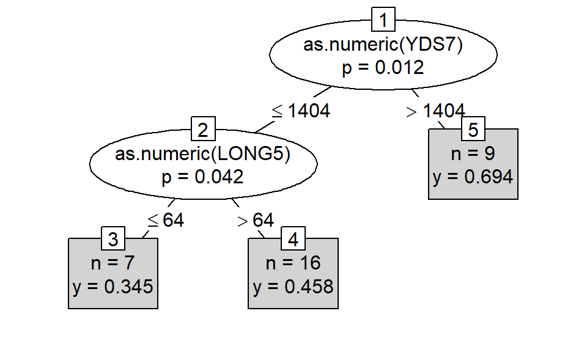

```r
mod1<-ctree(as.numeric(PCT)~as.numeric(YDS7)+as.numeric(LONG5),data=TotTeamData2017)
plot(mod1, type="simple")
```